# mQTL Meta-Analysis: PEG + PPMI

## 3.2 QQ Plots

```r
make_qq <- function(pvalues, title, color="steelblue", max_pts=1e6) {
  pvalues <- pvalues[!is.na(pvalues) & pvalues > 0 & pvalues <= 1]
  top     <- pvalues <= 1e-4
  if (sum(!top) > max_pts)
    pvalues <- c(pvalues[top],
                 sample(pvalues[!top], max_pts))
  n   <- length(pvalues)
  obs <- sort(-log10(pvalues))
  exp <- -log10(ppoints(n))
  ci_hi <- -log10(qbeta(0.025, seq_len(n), n - seq_len(n) + 1))
  ci_lo <- -log10(qbeta(0.975, seq_len(n), n - seq_len(n) + 1))

  ggplot(data.frame(exp=exp, obs=obs,
                    ci_hi=sort(ci_hi), ci_lo=sort(ci_lo)),
         aes(x=exp, y=obs)) +
    geom_ribbon(aes(ymin=ci_lo, ymax=ci_hi),
                fill="lightblue", alpha=0.4) +
    geom_point(size=0.5, alpha=0.5, color=color) +
    geom_abline(slope=1, intercept=0,
                color="red", linewidth=0.7) +
    labs(title    = title,
         subtitle = sprintf("n = %s", format(n, big.mark=",")),
         x="Expected  –log₁₀(p)",
         y="Observed  –log₁₀(p)") +
    theme_minimal(base_size=11) +
    theme(plot.subtitle=element_text(size=9, color="grey40"))
}
```

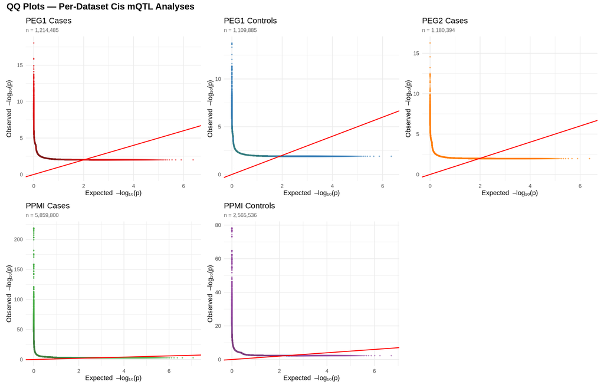

```r
qq_plots <- imap(mqtl_list, function(dat, nm)
  make_qq(dat$pvalue, DATASET_LABELS[nm], DATASET_COLORS[nm]))

wrap_plots(qq_plots, ncol=3) +
  plot_annotation(
    title = "QQ Plots — Per-Dataset Cis mQTL Analyses",
    theme = theme(plot.title=element_text(size=15, face="bold"))
  )
```

## 3.3 Effect Size Distributions

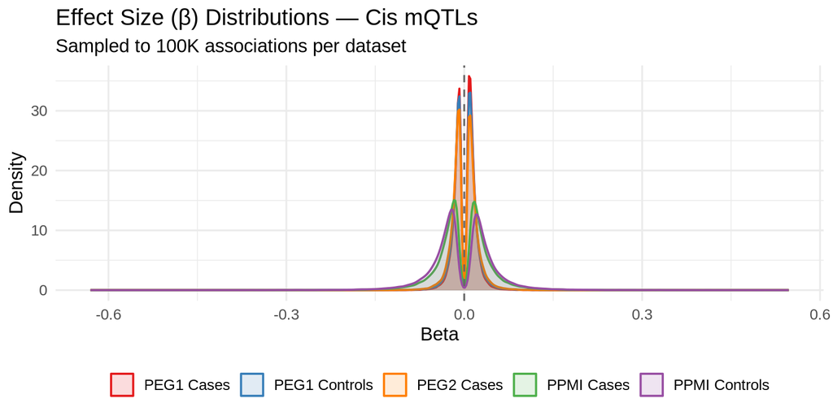

```r
imap_dfr(mqtl_list, function(dat, nm)
  dat %>%
    slice_sample(n=min(100000, nrow(dat))) %>%
    mutate(label=DATASET_LABELS[nm])
) %>%
  ggplot(aes(x=beta, color=dataset, fill=dataset)) +
  geom_density(alpha=0.15, linewidth=0.7) +
  scale_color_manual(values=DATASET_COLORS, labels=DATASET_LABELS) +
  scale_fill_manual( values=DATASET_COLORS, labels=DATASET_LABELS) +
  geom_vline(xintercept=0, linetype="dashed", color="grey40") +
  labs(title="Effect Size (β) Distributions — Cis mQTLs",
       subtitle="Sampled to 100K associations per dataset",
       x="Beta", y="Density", color=NULL, fill=NULL) +
  theme_minimal(base_size=13) +
  theme(legend.position="bottom")
```

# 4. Meta-Analysis with r-meta

## 4.1 Strategy

We use **fixed-effects inverse-variance weighted (IVW) meta-analysis** via `metagen()` from the `meta` package. Fixed effects is appropriate here because we are combining results from cohorts drawn from the same biological population — we want to estimate a common true effect, not the distribution of effects across populations.

For each SNP-CpG pair tested in multiple datasets:

- **Effect size:** β from MatrixEQTL
- **Standard error:** SE = |β / t-stat|
- **Method:** IVW fixed effects (`method.tau="DL"` for heterogeneity)
- **Heterogeneity:** Cochran’s Q and I² reported for significant hits

## 4.2 Run Meta-Analysis Per Group

```r
run_meta_group <- function(group_name, dataset_names) {
  cat(sprintf("\n=== %s meta-analysis ===\n", group_name))
  message(sprintf("\n=== %s meta-analysis ===\n", group_name))
  group_data <- mqtl_list[dataset_names]
  group_data <- Filter(Negate(is.null), group_data)

  if (length(group_data) == 0) {
    cat("No data available\n")
    return(NULL)
  }

  cat(sprintf("Datasets: %s\n", paste(names(group_data), collapse=", ")))
  message(sprintf("Datasets: %s\n", paste(names(group_data), collapse=", ")))
  # ── Strict intersection ───────────────────────────────────────────────────
  # Only meta-analyse pairs significant in ALL constituent datasets.
  # This is computationally tractable and focuses on robustly replicated signals.
  # Individual cohort thresholds are set permissively (pval_cis = 1e-3 for PEG,
  # 1e-5 for PPMI) so the intersection captures pairs that clear the bar in both.
  common_pairs <- Reduce(intersect, lapply(group_data, function(d) d$pair_id))
  cat(sprintf("SNP-CpG pairs in all datasets: %s\n",
      format(length(common_pairs), big.mark=",")))

  message(sprintf("SNP-CpG pairs in all datasets: %s\n",
      format(length(common_pairs), big.mark=",")))
  if (length(common_pairs) == 0) {
    cat("No common pairs — check SNP and probe intersection\n")
    return(NULL)
  }

  # Subset each dataset to common pairs and align
  aligned <- lapply(names(group_data), function(nm) {
    group_data[[nm]] %>%
      filter(pair_id %in% common_pairs) %>%
      select(pair_id, snp_id, cpg_id, beta, se, pvalue) %>%
      rename_with(~paste0(., "_", nm), c(beta, se, pvalue, snp_id, cpg_id))
  })

  # Inner join — all pairs present in all datasets by construction
  merged <- Reduce(function(a, b) inner_join(a, b, by="pair_id"), aligned)

  # Recover snp_id and cpg_id from first dataset
  first_nm <- names(group_data)[1]
  merged <- merged %>%
    rename(snp_id = paste0("snp_id_", first_nm),
           cpg_id = paste0("cpg_id_", first_nm)) %>%
    select(-matches("^snp_id_|^cpg_id_"))

  cat(sprintf("Pairs after alignment join: %s\n",
      format(nrow(merged), big.mark=",")))
  message(sprintf("Pairs after alignment join: %s\n",
      format(nrow(merged), big.mark=",")))

  beta_cols <- paste0("beta_", names(group_data))
  se_cols   <- paste0("se_",   names(group_data))

  cat("Running metagen()...\n")

  message("Running metagen()...\n")

  meta_results <- lapply(seq_len(nrow(merged)), function(i) {
    betas <- as.numeric(merged[i, beta_cols])
    ses   <- as.numeric(merged[i, se_cols])

    if (any(is.na(betas)) || any(is.na(ses)) || any(ses <= 0))
      return(NULL)

    mg <- tryCatch(
      metagen(TE=betas, seTE=ses,
              studlab    = names(group_data),
              method.tau = "DL",
              common     = TRUE,
              random     = FALSE),
      error = function(e) NULL
    )
    if (is.null(mg)) return(NULL)

    data.frame(
      pair_id    = merged$pair_id[i],
      snp_id     = merged$snp_id[i],
      cpg_id     = merged$cpg_id[i],
      meta_beta  = mg$TE.common,
      meta_se    = mg$seTE.common,
      meta_pval  = mg$pval.common,
      meta_z     = mg$zval.common,
      Q          = mg$Q,
      Q_pval     = mg$pval.Q,
      I2         = mg$I2,
      n_datasets = length(betas),
      stringsAsFactors = FALSE
    )
  })

  meta_df <- bind_rows(Filter(Negate(is.null), meta_results))

  if (nrow(meta_df) == 0) {
    cat("No results produced\n")
    return(NULL)
  }

  # FDR correction
  meta_df <- meta_df %>%
    arrange(meta_pval) %>%
    mutate(FDR_BH = p.adjust(meta_pval, method="BH"))

  cat(sprintf("Meta-analysis complete: %s pairs\n",
      format(nrow(meta_df), big.mark=",")))
  cat(sprintf("  FDR < 0.05: %s\n",
      format(sum(meta_df$FDR_BH < 0.05, na.rm=TRUE), big.mark=",")))
  cat(sprintf("  FDR < 0.10: %s\n",
      format(sum(meta_df$FDR_BH < 0.10, na.rm=TRUE), big.mark=",")))
  cat(sprintf("  p < 1e-8:   %s\n",
      format(sum(meta_df$meta_pval < 1e-8, na.rm=TRUE), big.mark=",")))

  # Save full results
  out_file <- file.path(META_DIR,
                         paste0(group_name, "_meta_results.csv.gz"))
  fwrite(meta_df, out_file)
  cat(sprintf("  Saved: %s\n", basename(out_file)))

  invisible(meta_df)
}

# NOTE: metagen() is called once per SNP-CpG pair.
# For large datasets this can take 30-60 minutes.
# Results are cached — delete cache/ to rerun.
meta_results <- list()
for (group in names(META_GROUPS)) {
  meta_results[[group]] <- run_meta_group(group, META_GROUPS[[group]])
}
```

```
##
## === cases meta-analysis ===
```

```
## Datasets: peg1_cases, ppmi_cases
```

```
## SNP-CpG pairs in all datasets: 30,785
```

```
## Pairs after alignment join: 30,785
```

```
## Running metagen()...
```

```
## Meta-analysis complete: 30,785 pairs
##   FDR < 0.05: 18,986
##   FDR < 0.10: 19,364
##   p < 1e-8:   3,890
##   Saved: cases_meta_results.csv.gz
##
## === controls meta-analysis ===
```

```
## Datasets: peg1_controls, ppmi_controls
```

```
## SNP-CpG pairs in all datasets: 34,984
```

```
## Pairs after alignment join: 34,984
```

```
## Running metagen()...
```

```
## Meta-analysis complete: 34,984 pairs
##   FDR < 0.05: 15,282
##   FDR < 0.10: 15,719
##   p < 1e-8:   448
##   Saved: controls_meta_results.csv.gz
```

```r
# ── Sensitivity analysis: 3-way intersection including PEG2 cases ─────────────
# PEG2 is cases-only (Wave 2). The 3-way PEG1 ∩ PEG2 ∩ PPMI intersection
# is very strict but identifies the most robustly replicated signals.
message("Running sensitivity analysis (PEG1 + PEG2 + PPMI cases 3-way)...")
sensitivity_results <- list()
for (group in names(SENSITIVITY_GROUPS)) {
  sensitivity_results[[group]] <- run_meta_group(
    group, SENSITIVITY_GROUPS[[group]])
}
```

```
##
## === cases_peg2_sensitivity meta-analysis ===
```

```
## Datasets: peg1_cases, peg2_cases, ppmi_cases
```

```
## SNP-CpG pairs in all datasets: 378
```

```
## Pairs after alignment join: 378
```

```
## Running metagen()...
```

```
## Meta-analysis complete: 378 pairs
##   FDR < 0.05: 154
##   FDR < 0.10: 160
##   p < 1e-8:   44
##   Saved: cases_peg2_sensitivity_meta_results.csv.gz
```

```r
# ── Flag primary cases hits also significant in PEG2 ─────────────────────────
if (!is.null(meta_results$cases) && nrow(meta_results$cases) > 0) {
  peg2_pairs <- mqtl_list$peg2_cases$pair_id
  meta_results$cases$in_peg2 <- meta_results$cases$pair_id %in% peg2_pairs
  message(sprintf("Primary cases hits also significant in PEG2: %d / %d",
      sum(meta_results$cases$in_peg2, na.rm=TRUE),
      nrow(meta_results$cases)))
}
```

# 5. Meta-Analysis Results

## 5.1 Summary

```r
summary_df <- imap_dfr(meta_results, function(dat, group) {
  if (is.null(dat) || nrow(dat) == 0) return(NULL)
  data.frame(
    group      = str_to_title(group),
    n_pairs    = nrow(dat),
    pct_fdr05  = round(100 * mean(dat$FDR_BH < 0.05, na.rm=TRUE), 1),
    n_fdr05    = sum(dat$FDR_BH    < 0.05, na.rm=TRUE),
    n_fdr10    = sum(dat$FDR_BH    < 0.10, na.rm=TRUE),
    n_p1e5     = sum(dat$meta_pval < 1e-5, na.rm=TRUE),
    n_p1e8     = sum(dat$meta_pval < 1e-8, na.rm=TRUE),
    n_in_peg2  = if ("in_peg2" %in% colnames(dat))
                   sum(dat$in_peg2, na.rm=TRUE) else NA,
    pct_het    = round(100 * mean(dat$Q_pval < 0.05, na.rm=TRUE), 1),
    stringsAsFactors = FALSE
  )
})

if (is.null(summary_df) || nrow(summary_df) == 0) {
  cat("No meta-analysis results available yet — run Section 4.2 first.
")
} else {
  summary_df %>%
    mutate(across(c(n_pairs, n_fdr05, n_fdr10, n_p1e5, n_p1e8, n_in_peg2),
                  ~format(.x, big.mark=","))) %>%
    knitr::kable(
      col.names = c("Group", "Pairs", "% FDR<0.05", "FDR<0.05",
                    "FDR<0.10", "p<1e-5", "p<1e-8",
                    "Also in PEG2", "% heterogeneous"),
      caption   = paste("Meta-analysis summary (Cases: PEG1 × PPMI two-way;",
                        "Controls: PEG1 × PPMI two-way).",
                        "'Also in PEG2' = primary hits also significant in PEG2",
                        "at pval_cis < 1e-3, providing three-cohort support.",
                        "FDR_BH computed on meta-analysis p-values.")
    )

}
```

Meta-analysis summary (Cases: PEG1 × PPMI two-way; Controls: PEG1 × PPMI two-way). ‘Also in PEG2’ = primary hits also significant in PEG2 at pval_cis < 1e-3, providing three-cohort support. FDR_BH computed on meta-analysis p-values.

| Group | Pairs | % FDR<0.05 | FDR<0.05 | FDR<0.10 | p<1e-5 | p<1e-8 | Also in PEG2 | % heterogeneous |
| --- | --- | --- | --- | --- | --- | --- | --- | --- |
| Cases | 30,785 | 61.7 | 18,986 | 19,364 | 13,583 | 3,890 | 378 | 62.6 |
| Controls | 34,984 | 43.7 | 15,282 | 15,719 | 3,617 | 448 | NA | 68.6 |

## 5.2 QQ Plots — Meta-Analysis

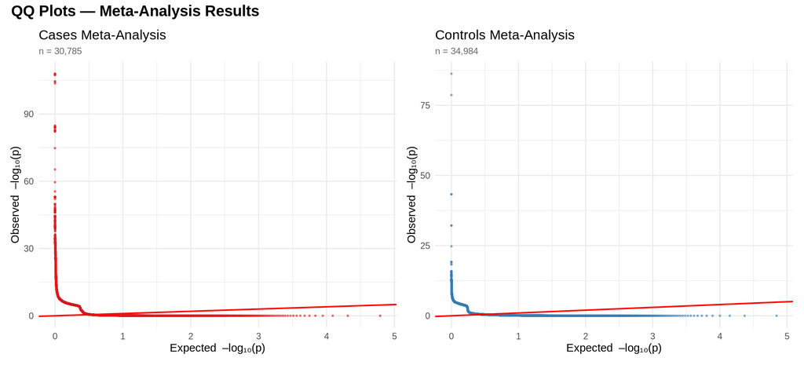

```r
meta_qq <- imap(meta_results, function(dat, group) {
  if (is.null(dat)) return(NULL)
  make_qq(dat$meta_pval,
          title = sprintf("%s Meta-Analysis", str_to_title(group)),
          color = ifelse(group=="cases", "#E41A1C", "#377EB8"))
})
meta_qq <- Filter(Negate(is.null), meta_qq)

if (length(meta_qq) > 0)
  wrap_plots(meta_qq, ncol=2) +
    plot_annotation(
      title = "QQ Plots — Meta-Analysis Results",
      theme = theme(plot.title=element_text(size=15, face="bold"))
    )
```

## 5.3 Top Meta-mQTLs

```r
fmt_pval <- function(x) {
  case_when(
    is.na(x)       ~ "NA",
    x < 1e-300     ~ "< 1e-300",
    x < 0.001      ~ formatC(x, format="e", digits=2),
    TRUE           ~ as.character(round(x, 4))
  )
}

for (group in names(meta_results)) {
  dat <- meta_results[[group]]
  if (is.null(dat) || nrow(dat) == 0) {
    cat(sprintf("\n### %s — no results\n", str_to_title(group)))
    next
  }

  cat(sprintf("\n### %s — Top 20\n", str_to_title(group)))

  top20 <- dat %>%
    arrange(meta_pval) %>%
    slice_head(n=20)

  # Pull per-study beta and p-value for each top pair
  datasets_in_group <- META_GROUPS[[group]]
  per_study <- lapply(datasets_in_group, function(nm) {
    mqtl_list[[nm]] %>%
      filter(pair_id %in% top20$pair_id) %>%
      select(pair_id, beta, pvalue) %>%
      rename_with(~paste0(nm, "_", .), c(beta, pvalue))
  })
  per_study_df <- Reduce(function(a, b)
    left_join(a, b, by="pair_id"), per_study)

  # Join per-study stats to top20
  top20 <- top20 %>%
    left_join(per_study_df, by="pair_id")

  # Build dynamic column list
  study_beta_cols <- paste0(datasets_in_group, "_beta")
  study_pval_cols <- paste0(datasets_in_group, "_pvalue")

  top20 %>%
    select(snp_id, cpg_id, meta_beta, meta_se,
           meta_pval, FDR_BH, I2, Q_pval,
           all_of(c(study_beta_cols, study_pval_cols))) %>%
    mutate(
      meta_beta = round(meta_beta, 4),
      meta_se   = round(meta_se,   4),
      meta_pval = fmt_pval(meta_pval),
      FDR_BH    = fmt_pval(FDR_BH),
      I2        = round(I2, 1),
      Q_pval    = fmt_pval(Q_pval),
      across(all_of(study_beta_cols), ~round(.x, 4)),
      across(all_of(study_pval_cols), ~fmt_pval(.x))
    ) %>%
    knitr::kable(
      col.names = c(
        "SNP", "CpG", "Meta β", "Meta SE",
        "Meta p", "FDR", "I²", "Q p",
        paste0(datasets_in_group, " β"),
        paste0(datasets_in_group, " p")
      ),
      caption = sprintf("Top 20 %s meta-mQTLs with per-study statistics",
                        group)
    ) %>%
    print()
}
```

```
##
## ### Cases — Top 20
##
##
## Table: Top 20 cases meta-mQTLs with per-study statistics
##
## |SNP         |CpG        |  Meta β| Meta SE|Meta p    |FDR       | I²|Q p      | peg1_cases β| ppmi_cases β|peg1_cases p |ppmi_cases p |
## |:-----------|:----------|-------:|-------:|:---------|:---------|--:|:--------|------------:|------------:|:------------|:------------|
## |8:628089    |cg01053087 |  0.2456|  0.0111|1.08e-108 |1.65e-104 |  1|1.46e-31 |       0.0586|       0.3354|0.0028       |5.84e-56     |
## |8:628003    |cg01053087 |  0.2455|  0.0111|1.10e-108 |1.65e-104 |  1|1.46e-31 |       0.0586|       0.3354|0.0028       |5.86e-56     |
## |8:627040    |cg01053087 |  0.2455|  0.0111|1.60e-108 |1.65e-104 |  1|9.77e-32 |       0.0577|       0.3355|0.0033       |5.65e-56     |
## |8:627181    |cg01053087 |  0.2451|  0.0111|3.84e-108 |2.70e-104 |  1|5.92e-32 |       0.0563|       0.3354|0.0042       |5.84e-56     |
## |8:627269    |cg01053087 |  0.2451|  0.0111|4.39e-108 |2.70e-104 |  1|6.05e-32 |       0.0563|       0.3354|0.0042       |6.03e-56     |
## |8:633684    |cg01053087 |  0.2436|  0.0112|2.41e-105 |1.24e-101 |  1|5.46e-32 |       0.0559|       0.3359|0.0044       |2.09e-55     |
## |8:633892    |cg01053087 |  0.2434|  0.0112|5.27e-105 |2.32e-101 |  1|5.94e-32 |       0.0559|       0.3358|0.0044       |2.50e-55     |
## |8:634921    |cg01053087 |  0.2433|  0.0112|2.45e-104 |9.41e-101 |  1|3.05e-32 |       0.0542|       0.3363|0.0059       |2.82e-55     |
## |5:157061963 |cg07464716 | -0.1387|  0.0071|1.39e-85  |4.76e-82  |  1|2.11e-30 |      -0.0334|      -0.2012|0.0043       |9.48e-51     |
## |5:157079630 |cg07464716 | -0.1405|  0.0072|2.86e-85  |8.80e-82  |  1|2.02e-31 |      -0.0334|      -0.2060|0.0044       |6.46e-51     |
## |5:157063194 |cg07464716 | -0.1385|  0.0071|5.33e-85  |1.37e-81  |  1|2.40e-30 |      -0.0333|      -0.2012|0.0044       |1.33e-50     |
## |5:157064500 |cg07464716 | -0.1385|  0.0071|5.36e-85  |1.37e-81  |  1|2.37e-30 |      -0.0334|      -0.2012|0.0043       |1.33e-50     |
## |5:157066471 |cg07464716 | -0.1384|  0.0071|9.47e-85  |2.09e-81  |  1|2.64e-30 |      -0.0334|      -0.2011|0.0043       |1.56e-50     |
## |5:157067030 |cg07464716 | -0.1384|  0.0071|9.50e-85  |2.09e-81  |  1|2.63e-30 |      -0.0334|      -0.2011|0.0043       |1.56e-50     |
## |5:157044476 |cg07464716 | -0.1382|  0.0071|1.49e-84  |2.98e-81  |  1|7.57e-30 |      -0.0336|      -0.2001|0.0042       |2.24e-50     |
## |5:157043663 |cg07464716 | -0.1382|  0.0071|1.55e-84  |2.98e-81  |  1|7.66e-30 |      -0.0336|      -0.2001|0.0042       |2.27e-50     |
## |5:157086041 |cg07464716 | -0.1396|  0.0072|1.52e-83  |2.61e-80  |  1|3.99e-31 |      -0.0334|      -0.2056|0.0044       |1.92e-50     |
## |5:157085814 |cg07464716 | -0.1396|  0.0072|1.53e-83  |2.61e-80  |  1|3.97e-31 |      -0.0334|      -0.2056|0.0044       |1.92e-50     |
## |5:157083004 |cg07464716 | -0.1396|  0.0072|2.09e-83  |3.39e-80  |  1|3.83e-31 |      -0.0334|      -0.2057|0.0044       |2.05e-50     |
## |5:157087289 |cg07464716 | -0.1394|  0.0072|4.43e-83  |6.82e-80  |  1|4.53e-31 |      -0.0334|      -0.2055|0.0044       |2.55e-50     |
##
## ### Controls — Top 20
##
##
## Table: Top 20 controls meta-mQTLs with per-study statistics
##
## |SNP         |CpG        |  Meta β| Meta SE|Meta p   |FDR      |  I²|Q p      | peg1_controls β| ppmi_controls β|peg1_controls p |ppmi_controls p |
## |:-----------|:----------|-------:|-------:|:--------|:--------|---:|:--------|---------------:|---------------:|:---------------|:---------------|
## |12:56359878 |cg00635560 | -0.1719|  0.0087|5.33e-87 |1.87e-82 | 1.0|1.71e-44 |          0.0487|         -0.2390|0.0074          |1.51e-31        |
```

[output cut: 19 more lines]